# Reproducible Research - Peer Assessment 1

## Biplab Mazumder

The Assignment is to analyze daily activity Pattern from a personal activity monitoring device.

### Loading and Analysing the Data

```r
DataSetFname<-"../Dataset/activity.csv"
df<-read.csv(DataSetFname)
```

### Calculate Mean Total number of Steps taken per day

First let’s calulate the total number of steps per day

```r
totalsteps<-tapply(df$steps,df$date,FUN=sum,na.rm=TRUE)
```

Then let’s plot it in a histogram

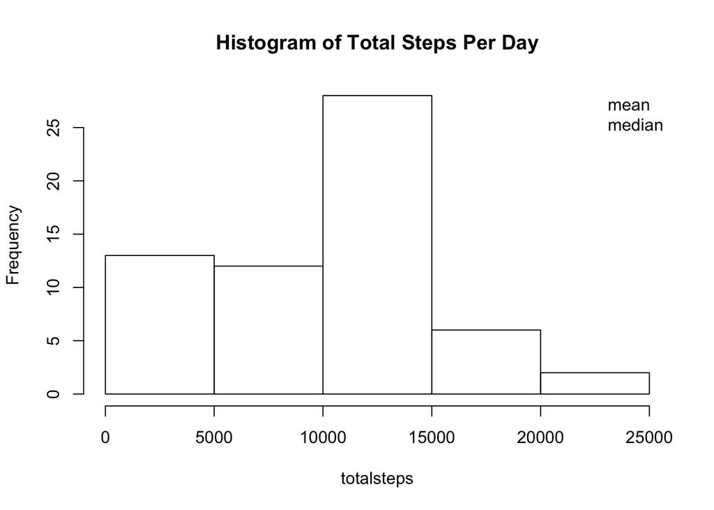

```r
hist(totalsteps,main="Histogram of Total Steps Per Day")
legend(x="topright", legend=c("mean","median"), col=c("red","blue"), bty="n")
```

Second Calculate the mean and median and ofcourse represent it in the earlier hstogram

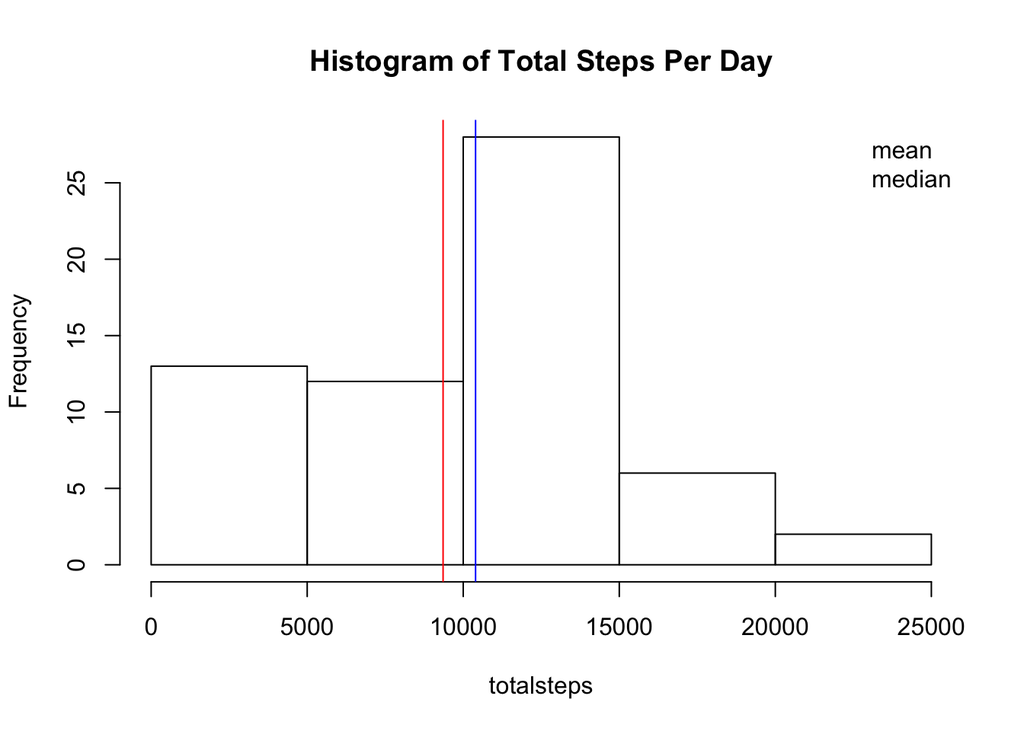

```r
totalsteps.min<-mean(totalsteps)
totalsteps.median<-median(totalsteps)
hist(totalsteps,main="Histogram of Total Steps Per Day")
legend(x="topright", legend=c("mean","median"), col=c("red","blue"), bty="n")
abline(v=totalsteps.min,col="red")
abline(v=totalsteps.median,col="blue")
```

### What is the average daily activity pattern

Making a time series plot of the 5 min interval and the average number of steps taken

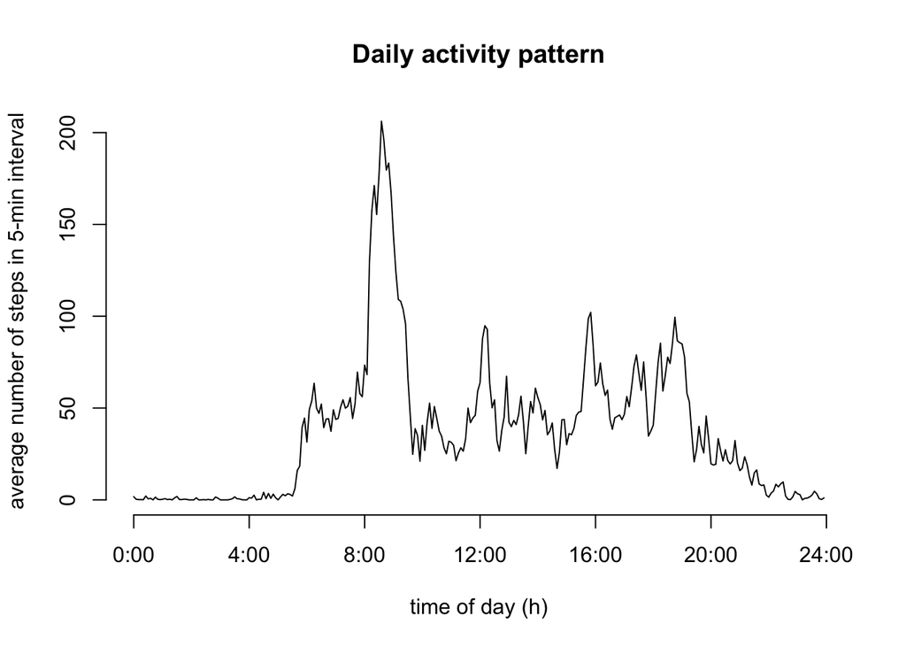

```r
df$interval <- 60*floor((df$interval+1)/100) + (df$interval %% 100)
avg_steps<-tapply(df$steps,df$interval,mean,na.rm=T)
avgStepsPerHr<-as.numeric(names(avg_steps))/60
plot(avgStepsPerHr, avg_steps, type="l", axes=F,
     xlab="time of day (h)", ylab="average number of steps in 5-min interval",
     main="Daily activity pattern")
axis(2)
axis(1, at=0:6*4, labels=paste(0:6*4,":00", sep=""))
```

Now we will find out which 5-minute interval, on average across all the days in the dataset, contains the maximum number of steps.

```r
max_steps <- which(avg_steps==max(avg_steps))
max_steps_int <- df$interval[max_steps]
sprintf("%02d:%02d", floor(max_steps_int/60), max_steps_int %% 60)
```

```
## [1] "08:35"
```

### Inputing Missing Values

There are a number of Days/Intervals which have missing values. The task is to find out the number of missing values and a strategy to fill up the missing values

Firstly, Calculate the total number of missing values :

```r
sum(is.na(df))
```

```
## [1] 2304
```

Strategy to fill up the missing values: for every missing value, we will take the average number of steps in thet 5 min interval. This procedure will work good, if the person has daily routines

```r
df.filledna <- transform(df, steps=ifelse(is.na(steps), avg_steps, steps))
```

Now make the the earlier histogram , but with this new filled up dataset.

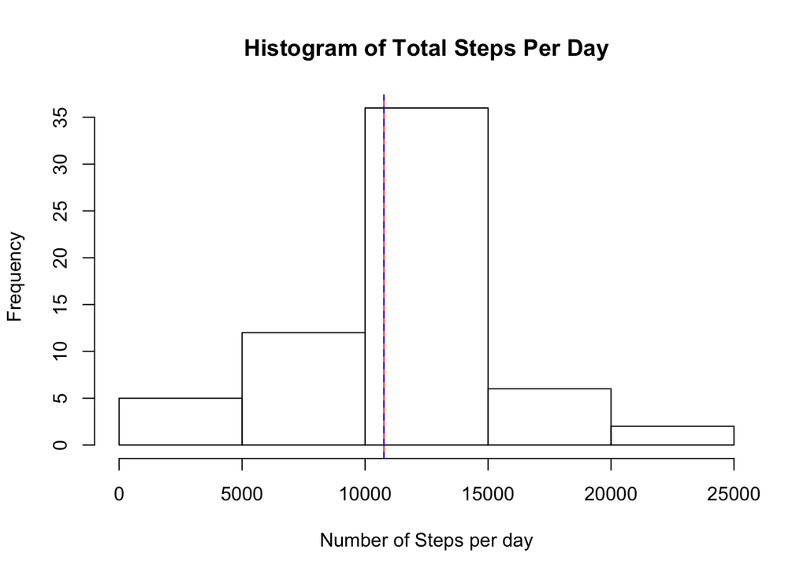

```r
totalsteps<-tapply(df.filledna$steps,df.filledna$date,FUN=sum,na.rm=TRUE)
totalsteps.min<-mean(totalsteps)
totalsteps.median<-median(totalsteps)
hist(totalsteps,main="Histogram of Total Steps Per Day",xlab="Number of Steps per day")
abline(v=totalsteps.min,col="red")
abline(v=totalsteps.median,col="blue",lty=2)
```

Find the difference on the number of steps between the earlier dataset(ignoring NAs) and the new dataset created by filling up the missing values

```r
sum(df$steps,na.rm=T)
```

```
## [1] 570608
```

```r
sum(df.filledna$steps)
```

```
## [1] 656737.5
```

So it seems there is a substantial increase in the number of footsteps between the original dataset and the filled up dataset.

### Difference in activity patterns between weeekdays and weekends

```r
library(plyr)
df.filledna$weekdays <- weekdays(as.Date(df.filledna$date))
df.filledna$weekdays <- ifelse(df.filledna$weekdays %in% c("Saturday", "Sunday"),"weekend", "weekday")
average <- ddply(df.filledna, .(interval, weekdays), summarise, steps=mean(steps))
```

Making a panel plot containing a time series plot of the 5 min interval and the average number of steps taken:

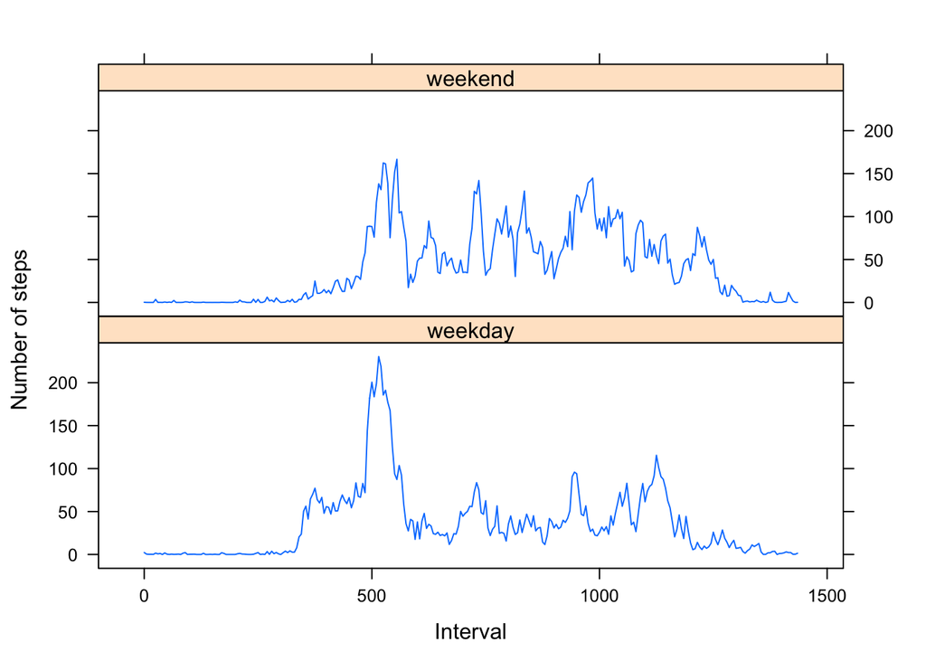

```r
library(lattice)
xyplot(steps ~ interval | weekdays, data = average, layout = c(1, 2), type="l", xlab = "Interval", ylab = "Number of steps")
```